# Optimal Treatment Analysis

## Outcome Variable

**Outcome Variable:** whz

## Predictor Variables

**Intervention Variable:** mbmi

**Adjustment Set:**

- arm
- W_mage
- meducyrs
- feducyrs
- single
- brthmon
- W_parity
- delta_W_mage
- delta_meducyrs
- delta_feducyrs
- delta_single
- delta_brthmon
- delta_W_parity

## Stratifying Variables

The analysis was stratified on these variable(s):

- agecat
- studyid
- country

## Data Summary

| agecat | studyid | country | mbmi | n_cell | n |
| --- | --- | --- | --- | --- | --- |
| Birth | JiVitA-3 | BANGLADESH | Normal weight | 10934 | 17935 |
| Birth | JiVitA-3 | BANGLADESH | Underweight | 7001 | 17935 |
| Birth | MAL-ED | BANGLADESH | Normal weight | 183 | 209 |
| Birth | MAL-ED | BANGLADESH | Underweight | 26 | 209 |
| Birth | MAL-ED | BRAZIL | Normal weight | 56 | 61 |
| Birth | MAL-ED | BRAZIL | Underweight | 5 | 61 |
| Birth | MAL-ED | INDIA | Normal weight | 33 | 41 |
| Birth | MAL-ED | INDIA | Underweight | 8 | 41 |
| Birth | MAL-ED | NEPAL | Normal weight | 26 | 26 |
| Birth | MAL-ED | NEPAL | Underweight | 0 | 26 |
| Birth | MAL-ED | PERU | Normal weight | 216 | 221 |
| Birth | MAL-ED | PERU | Underweight | 5 | 221 |
| Birth | MAL-ED | SOUTH AFRICA | Normal weight | 97 | 100 |
| Birth | MAL-ED | SOUTH AFRICA | Underweight | 3 | 100 |
| Birth | MAL-ED | TANZANIA, UNITED REPUBLIC OF | Normal weight | 107 | 113 |
| Birth | MAL-ED | TANZANIA, UNITED REPUBLIC OF | Underweight | 6 | 113 |
| Birth | NIH-Birth | BANGLADESH | Normal weight | 483 | 575 |
| Birth | NIH-Birth | BANGLADESH | Underweight | 92 | 575 |
| Birth | NIH-Crypto | BANGLADESH | Normal weight | 639 | 704 |
| Birth | NIH-Crypto | BANGLADESH | Underweight | 65 | 704 |
| Birth | PROBIT | BELARUS | Normal weight | 13130 | 13651 |
| Birth | PROBIT | BELARUS | Underweight | 521 | 13651 |
| Birth | PROVIDE | BANGLADESH | Normal weight | 411 | 510 |
| Birth | PROVIDE | BANGLADESH | Underweight | 99 | 510 |
| Birth | SAS-CompFeed | INDIA | Normal weight | 735 | 992 |
| Birth | SAS-CompFeed | INDIA | Underweight | 257 | 992 |
| Birth | ZVITAMBO | ZIMBABWE | Normal weight | 8574 | 9030 |
| Birth | ZVITAMBO | ZIMBABWE | Underweight | 456 | 9030 |
| 6 months | JiVitA-3 | BANGLADESH | Normal weight | 10303 | 16733 |
| 6 months | JiVitA-3 | BANGLADESH | Underweight | 6430 | 16733 |

[output cut: 60 more lines]

The following strata were considered:

- agecat: 24 months, studyid: JiVitA-3, country: BANGLADESH
- agecat: 24 months, studyid: LCNI-5, country: MALAWI
- agecat: 24 months, studyid: MAL-ED, country: BANGLADESH
- agecat: 24 months, studyid: MAL-ED, country: BRAZIL
- agecat: 24 months, studyid: MAL-ED, country: INDIA
- agecat: 24 months, studyid: MAL-ED, country: NEPAL
- agecat: 24 months, studyid: MAL-ED, country: PERU
- agecat: 24 months, studyid: MAL-ED, country: SOUTH AFRICA
- agecat: 24 months, studyid: MAL-ED, country: TANZANIA, UNITED REPUBLIC OF
- agecat: 24 months, studyid: NIH-Birth, country: BANGLADESH
- agecat: 24 months, studyid: NIH-Crypto, country: BANGLADESH
- agecat: 24 months, studyid: PROBIT, country: BELARUS
- agecat: 24 months, studyid: PROVIDE, country: BANGLADESH
- agecat: 24 months, studyid: TanzaniaChild2, country: TANZANIA, UNITED REPUBLIC OF
- agecat: 24 months, studyid: ZVITAMBO, country: ZIMBABWE
- agecat: 6 months, studyid: JiVitA-3, country: BANGLADESH
- agecat: 6 months, studyid: LCNI-5, country: MALAWI
- agecat: 6 months, studyid: MAL-ED, country: BANGLADESH
- agecat: 6 months, studyid: MAL-ED, country: BRAZIL
- agecat: 6 months, studyid: MAL-ED, country: INDIA
- agecat: 6 months, studyid: MAL-ED, country: NEPAL
- agecat: 6 months, studyid: MAL-ED, country: PERU
- agecat: 6 months, studyid: MAL-ED, country: SOUTH AFRICA
- agecat: 6 months, studyid: MAL-ED, country: TANZANIA, UNITED REPUBLIC OF
- agecat: 6 months, studyid: NIH-Birth, country: BANGLADESH
- agecat: 6 months, studyid: NIH-Crypto, country: BANGLADESH
- agecat: 6 months, studyid: PROBIT, country: BELARUS
- agecat: 6 months, studyid: PROVIDE, country: BANGLADESH
- agecat: 6 months, studyid: SAS-CompFeed, country: INDIA
- agecat: 6 months, studyid: TanzaniaChild2, country: TANZANIA, UNITED REPUBLIC OF
- agecat: 6 months, studyid: ZVITAMBO, country: ZIMBABWE
- agecat: Birth, studyid: JiVitA-3, country: BANGLADESH
- agecat: Birth, studyid: MAL-ED, country: BANGLADESH
- agecat: Birth, studyid: MAL-ED, country: BRAZIL
- agecat: Birth, studyid: MAL-ED, country: INDIA
- agecat: Birth, studyid: MAL-ED, country: NEPAL
- agecat: Birth, studyid: MAL-ED, country: PERU
- agecat: Birth, studyid: MAL-ED, country: SOUTH AFRICA
- agecat: Birth, studyid: MAL-ED, country: TANZANIA, UNITED REPUBLIC OF
- agecat: Birth, studyid: NIH-Birth, country: BANGLADESH
- agecat: Birth, studyid: NIH-Crypto, country: BANGLADESH
- agecat: Birth, studyid: PROBIT, country: BELARUS
- agecat: Birth, studyid: PROVIDE, country: BANGLADESH
- agecat: Birth, studyid: SAS-CompFeed, country: INDIA
- agecat: Birth, studyid: ZVITAMBO, country: ZIMBABWE

### Dropped Strata

Some strata were dropped due to rare outcomes:

- agecat: Birth, studyid: MAL-ED, country: NEPAL
- agecat: Birth, studyid: MAL-ED, country: SOUTH AFRICA
- agecat: 6 months, studyid: MAL-ED, country: NEPAL
- agecat: 24 months, studyid: MAL-ED, country: NEPAL
- agecat: 24 months, studyid: MAL-ED, country: PERU
- agecat: 24 months, studyid: TanzaniaChild2, country: TANZANIA, UNITED REPUBLIC OF

## Methods Detail

We’re interested in the causal parameters $E[Y_a]$ for all values of $a \in \mathcal{A}$. These parameters represent the mean outcome if, possibly contrary to fact, we intervened to set all units to have $A=a$. Under the randomization and positivity assumptions, these are identified by the statistical parameters $\psi_a=E_W[E_{Y|A,W}(Y|A=a,W)]$. In addition, we’re interested in the mean of $Y$, $E[Y]$ under no intervention (the observed mean). We will estimate these parameters by using SuperLearner to fit the relevant likelihood factors – $E_{Y|A,W}(Y|A=a,W)$ and $p(A=a|W)$, and then updating our likelihood fit using a joint TMLE.

For unadjusted analyses ($W=\{\}$), initial likelihoods were estimated using Lrnr_glm to estimate the simple $E(Y|A)$ and Lrnr_mean to estimate $p(A)$. For adjusted analyses, a small library containing Lrnr_glmnet, Lrnr_xgboost, and Lrnr_mean was used.

Having estimated these parameters, we will then use the delta method to estimate relative risks and attributable risks relative to a prespecified baseline level of $A$.

# Results Detail

## Results Plots

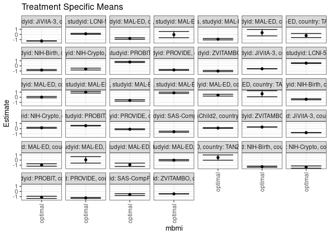

## Results Table

### Parameter: TSM

| agecat | studyid | country | intervention_level | baseline_level | estimate | ci_lower | ci_upper |
| --- | --- | --- | --- | --- | --- | --- | --- |
| Birth | JiVitA-3 | BANGLADESH | optimal | observed | -0.7758402 | -0.8002210 | -0.7514595 |
| Birth | MAL-ED | BANGLADESH | optimal | observed | -0.9614608 | -1.2025859 | -0.7203356 |
| Birth | MAL-ED | BRAZIL | optimal | observed | 0.0410412 | -0.5900858 | 0.6721682 |
| Birth | MAL-ED | INDIA | optimal | observed | -0.9196687 | -1.2483693 | -0.5909682 |
| Birth | MAL-ED | PERU | optimal | observed | -0.0279514 | -0.1524156 | 0.0965128 |
| Birth | MAL-ED | TANZANIA, UNITED REPUBLIC OF | optimal | observed | 0.4878265 | -0.0191596 | 0.9948126 |
| Birth | NIH-Birth | BANGLADESH | optimal | observed | -1.2897637 | -1.3945600 | -1.1849674 |
| Birth | NIH-Crypto | BANGLADESH | optimal | observed | -1.3670216 | -1.5868924 | -1.1471509 |
| Birth | PROBIT | BELARUS | optimal | observed | -1.1438300 | -1.3554452 | -0.9322148 |
| Birth | PROVIDE | BANGLADESH | optimal | observed | -1.2564487 | -1.3433687 | -1.1695286 |
| Birth | SAS-CompFeed | INDIA | optimal | observed | -0.6021087 | -0.7787134 | -0.4255040 |
| Birth | ZVITAMBO | ZIMBABWE | optimal | observed | -0.4688129 | -0.5005754 | -0.4370505 |
| 6 months | JiVitA-3 | BANGLADESH | optimal | observed | -0.5669151 | -0.5898107 | -0.5440195 |
| 6 months | LCNI-5 | MALAWI | optimal | observed | 0.5305558 | 0.4524365 | 0.6086750 |
| 6 months | MAL-ED | BANGLADESH | optimal | observed | 0.0204801 | -0.1109349 | 0.1518951 |
| 6 months | MAL-ED | BRAZIL | optimal | observed | 0.9785378 | 0.8102308 | 1.1468448 |
| 6 months | MAL-ED | INDIA | optimal | observed | -0.6130496 | -0.7553438 | -0.4707554 |
| 6 months | MAL-ED | PERU | optimal | observed | 0.8735039 | 0.7486417 | 0.9983660 |
| 6 months | MAL-ED | SOUTH AFRICA | optimal | observed | 0.4115002 | 0.2296326 | 0.5933678 |
| 6 months | MAL-ED | TANZANIA, UNITED REPUBLIC OF | optimal | observed | 0.6896037 | 0.1033307 | 1.2758766 |
| 6 months | NIH-Birth | BANGLADESH | optimal | observed | -0.3908080 | -0.4946354 | -0.2869805 |
| 6 months | NIH-Crypto | BANGLADESH | optimal | observed | 0.1716717 | 0.0740347 | 0.2693088 |
| 6 months | PROBIT | BELARUS | optimal | observed | 0.5861575 | 0.5280335 | 0.6442815 |
| 6 months | PROVIDE | BANGLADESH | optimal | observed | -0.1088938 | -0.1983521 | -0.0194354 |
| 6 months | SAS-CompFeed | INDIA | optimal | observed | -0.5905180 | -0.7083892 | -0.4726467 |
| 6 months | TanzaniaChild2 | TANZANIA, UNITED REPUBLIC OF | optimal | observed | 0.1261678 | 0.0486846 | 0.2036510 |
| 6 months | ZVITAMBO | ZIMBABWE | optimal | observed | 0.3152468 | 0.2870996 | 0.3433940 |
| 24 months | JiVitA-3 | BANGLADESH | optimal | observed | -1.2653280 | -1.2968059 | -1.2338502 |
| 24 months | LCNI-5 | MALAWI | optimal | observed | 0.1345555 | 0.0416470 | 0.2274639 |
| 24 months | MAL-ED | BANGLADESH | optimal | observed | -0.7806378 | -0.9227823 | -0.6384934 |
| 24 months | MAL-ED | BRAZIL | optimal | observed | -0.0307705 | -0.6362945 | 0.5747535 |
| 24 months | MAL-ED | INDIA | optimal | observed | -0.9299596 | -1.0666728 | -0.7932465 |
| 24 months | MAL-ED | SOUTH AFRICA | optimal | observed | 0.3490015 | -0.2747520 | 0.9727549 |
| 24 months | MAL-ED | TANZANIA, UNITED REPUBLIC OF | optimal | observed | -0.2145807 | -0.6142633 | 0.1851018 |
| 24 months | NIH-Birth | BANGLADESH | optimal | observed | -0.8166606 | -0.9199293 | -0.7133920 |
| 24 months | NIH-Crypto | BANGLADESH | optimal | observed | -0.6212606 | -0.8039228 | -0.4385984 |
| 24 months | PROBIT | BELARUS | optimal | observed | 0.7541459 | 0.6554615 | 0.8528304 |
| 24 months | PROVIDE | BANGLADESH | optimal | observed | -0.7981189 | -0.8877880 | -0.7084499 |
| 24 months | ZVITAMBO | ZIMBABWE | optimal | observed | -1.0074678 | -1.1191971 | -0.8957385 |

### Parameter: E(Y)

| agecat | studyid | country | intervention_level | baseline_level | estimate | ci_lower | ci_upper |
| --- | --- | --- | --- | --- | --- | --- | --- |
| Birth | JiVitA-3 | BANGLADESH | observed | observed | -0.7781583 | -0.7971779 | -0.7591388 |
| Birth | MAL-ED | BANGLADESH | observed | observed | -0.9533493 | -1.0984355 | -0.8082631 |
| Birth | MAL-ED | BRAZIL | observed | observed | 0.4018033 | 0.0834093 | 0.7201973 |
| Birth | MAL-ED | INDIA | observed | observed | -0.9678049 | -1.2522118 | -0.6833979 |
| Birth | MAL-ED | PERU | observed | observed | -0.0429864 | -0.1658406 | 0.0798678 |
| Birth | MAL-ED | TANZANIA, UNITED REPUBLIC OF | observed | observed | 0.7583186 | 0.5636385 | 0.9529987 |
| Birth | NIH-Birth | BANGLADESH | observed | observed | -1.3499217 | -1.4444634 | -1.2553801 |
| Birth | NIH-Crypto | BANGLADESH | observed | observed | -1.2434730 | -1.3276901 | -1.1592559 |
| Birth | PROBIT | BELARUS | observed | observed | -1.1472584 | -1.3582745 | -0.9362424 |
| Birth | PROVIDE | BANGLADESH | observed | observed | -1.3060980 | -1.3843247 | -1.2278714 |
| Birth | SAS-CompFeed | INDIA | observed | observed | -0.6752218 | -0.8548888 | -0.4955547 |
| Birth | ZVITAMBO | ZIMBABWE | observed | observed | -0.4905338 | -0.5214551 | -0.4596125 |
| 6 months | JiVitA-3 | BANGLADESH | observed | observed | -0.5931545 | -0.6127055 | -0.5736036 |
| 6 months | LCNI-5 | MALAWI | observed | observed | 0.4515550 | 0.3802638 | 0.5228463 |
| 6 months | MAL-ED | BANGLADESH | observed | observed | -0.1376763 | -0.2664642 | -0.0088885 |
| 6 months | MAL-ED | BRAZIL | observed | observed | 0.9648518 | 0.8004118 | 1.1292917 |
| 6 months | MAL-ED | INDIA | observed | observed | -0.7034149 | -0.8300527 | -0.5767771 |
| 6 months | MAL-ED | PERU | observed | observed | 1.0548591 | 0.9328922 | 1.1768259 |
| 6 months | MAL-ED | SOUTH AFRICA | observed | observed | 0.5291499 | 0.3751396 | 0.6831602 |
| 6 months | MAL-ED | TANZANIA, UNITED REPUBLIC OF | observed | observed | 0.5362213 | 0.4049390 | 0.6675036 |
| 6 months | NIH-Birth | BANGLADESH | observed | observed | -0.4474038 | -0.5378167 | -0.3569909 |
| 6 months | NIH-Crypto | BANGLADESH | observed | observed | 0.0297622 | -0.0491685 | 0.1086930 |
| 6 months | PROBIT | BELARUS | observed | observed | 0.5785149 | 0.5197782 | 0.6372516 |
| 6 months | PROVIDE | BANGLADESH | observed | observed | -0.1987071 | -0.2815473 | -0.1158669 |
| 6 months | SAS-CompFeed | INDIA | observed | observed | -0.6426305 | -0.7702214 | -0.5150396 |
| 6 months | TanzaniaChild2 | TANZANIA, UNITED REPUBLIC OF | observed | observed | 0.0775172 | 0.0241750 | 0.1308595 |
| 6 months | ZVITAMBO | ZIMBABWE | observed | observed | 0.2948332 | 0.2672524 | 0.3224139 |
| 24 months | JiVitA-3 | BANGLADESH | observed | observed | -1.2970642 | -1.3203662 | -1.2737621 |
| 24 months | LCNI-5 | MALAWI | observed | observed | -0.0468717 | -0.1290135 | 0.0352701 |
| 24 months | MAL-ED | BANGLADESH | observed | observed | -0.8192925 | -0.9412667 | -0.6973182 |
| 24 months | MAL-ED | BRAZIL | observed | observed | 0.4443651 | 0.2404149 | 0.6483153 |
| 24 months | MAL-ED | INDIA | observed | observed | -0.9519248 | -1.0678488 | -0.8360007 |
| 24 months | MAL-ED | SOUTH AFRICA | observed | observed | 0.3916417 | 0.2704414 | 0.5128421 |
| 24 months | MAL-ED | TANZANIA, UNITED REPUBLIC OF | observed | observed | 0.0547975 | -0.0703378 | 0.1799328 |
| 24 months | NIH-Birth | BANGLADESH | observed | observed | -0.9115790 | -1.0095022 | -0.8136559 |
| 24 months | NIH-Crypto | BANGLADESH | observed | observed | -0.6103502 | -0.7050157 | -0.5156847 |
| 24 months | PROBIT | BELARUS | observed | observed | 0.6991214 | 0.5821715 | 0.8160713 |
| 24 months | PROVIDE | BANGLADESH | observed | observed | -0.8914360 | -0.9741797 | -0.8086923 |
| 24 months | ZVITAMBO | ZIMBABWE | observed | observed | -1.1718579 | -1.2809898 | -1.0627260 |

### Parameter: PAR

| agecat | studyid | country | intervention_level | baseline_level | estimate | ci_lower | ci_upper |
| --- | --- | --- | --- | --- | --- | --- | --- |
| Birth | JiVitA-3 | BANGLADESH | optimal | observed | -0.0023181 | -0.0168047 | 0.0121685 |
| Birth | MAL-ED | BANGLADESH | optimal | observed | 0.0081115 | -0.1719689 | 0.1881918 |
| Birth | MAL-ED | BRAZIL | optimal | observed | 0.3607621 | -0.1843718 | 0.9058960 |
| Birth | MAL-ED | INDIA | optimal | observed | -0.0481361 | -0.1818223 | 0.0855500 |
| Birth | MAL-ED | PERU | optimal | observed | -0.0150350 | -0.0347537 | 0.0046836 |
| Birth | MAL-ED | TANZANIA, UNITED REPUBLIC OF | optimal | observed | 0.2704921 | -0.2363355 | 0.7773196 |
| Birth | NIH-Birth | BANGLADESH | optimal | observed | -0.0601580 | -0.0985309 | -0.0217852 |
| Birth | NIH-Crypto | BANGLADESH | optimal | observed | 0.1235486 | -0.0792726 | 0.3263698 |
| Birth | PROBIT | BELARUS | optimal | observed | -0.0034285 | -0.0115748 | 0.0047179 |
| Birth | PROVIDE | BANGLADESH | optimal | observed | -0.0496494 | -0.0878469 | -0.0114519 |
| Birth | SAS-CompFeed | INDIA | optimal | observed | -0.0731131 | -0.1185292 | -0.0276969 |
| Birth | ZVITAMBO | ZIMBABWE | optimal | observed | -0.0217208 | -0.0292521 | -0.0141895 |
| 6 months | JiVitA-3 | BANGLADESH | optimal | observed | -0.0262395 | -0.0402134 | -0.0122656 |
| 6 months | LCNI-5 | MALAWI | optimal | observed | -0.0790008 | -0.1120420 | -0.0459596 |
| 6 months | MAL-ED | BANGLADESH | optimal | observed | -0.1581564 | -0.2445121 | -0.0718007 |
| 6 months | MAL-ED | BRAZIL | optimal | observed | -0.0136860 | -0.0483440 | 0.0209720 |
| 6 months | MAL-ED | INDIA | optimal | observed | -0.0903653 | -0.1906060 | 0.0098753 |
| 6 months | MAL-ED | PERU | optimal | observed | 0.1813552 | 0.1161591 | 0.2465513 |
| 6 months | MAL-ED | SOUTH AFRICA | optimal | observed | 0.1176497 | 0.0237079 | 0.2115915 |
| 6 months | MAL-ED | TANZANIA, UNITED REPUBLIC OF | optimal | observed | -0.1533823 | -0.7196676 | 0.4129029 |
| 6 months | NIH-Birth | BANGLADESH | optimal | observed | -0.0565958 | -0.1105555 | -0.0026361 |
| 6 months | NIH-Crypto | BANGLADESH | optimal | observed | -0.1419095 | -0.2131722 | -0.0706468 |
| 6 months | PROBIT | BELARUS | optimal | observed | -0.0076425 | -0.0119738 | -0.0033112 |
| 6 months | PROVIDE | BANGLADESH | optimal | observed | -0.0898133 | -0.1308366 | -0.0487900 |
| 6 months | SAS-CompFeed | INDIA | optimal | observed | -0.0521125 | -0.0724616 | -0.0317635 |
| 6 months | TanzaniaChild2 | TANZANIA, UNITED REPUBLIC OF | optimal | observed | -0.0486506 | -0.1048545 | 0.0075534 |
| 6 months | ZVITAMBO | ZIMBABWE | optimal | observed | -0.0204136 | -0.0274940 | -0.0133332 |
| 24 months | JiVitA-3 | BANGLADESH | optimal | observed | -0.0317361 | -0.0524468 | -0.0110255 |
| 24 months | LCNI-5 | MALAWI | optimal | observed | -0.1814271 | -0.2430934 | -0.1197609 |
| 24 months | MAL-ED | BANGLADESH | optimal | observed | -0.0386546 | -0.1069537 | 0.0296444 |
| 24 months | MAL-ED | BRAZIL | optimal | observed | 0.4751356 | -0.1034129 | 1.0536841 |
| 24 months | MAL-ED | INDIA | optimal | observed | -0.0219651 | -0.1176510 | 0.0737207 |
| 24 months | MAL-ED | SOUTH AFRICA | optimal | observed | 0.0426403 | -0.5740500 | 0.6593306 |
| 24 months | MAL-ED | TANZANIA, UNITED REPUBLIC OF | optimal | observed | 0.2693782 | -0.1046614 | 0.6434179 |
| 24 months | NIH-Birth | BANGLADESH | optimal | observed | -0.0949184 | -0.1491293 | -0.0407075 |
| 24 months | NIH-Crypto | BANGLADESH | optimal | observed | 0.0109105 | -0.1359885 | 0.1578094 |
| 24 months | PROBIT | BELARUS | optimal | observed | -0.0550245 | -0.1125078 | 0.0024587 |
| 24 months | PROVIDE | BANGLADESH | optimal | observed | -0.0933171 | -0.1345229 | -0.0521112 |
| 24 months | ZVITAMBO | ZIMBABWE | optimal | observed | -0.1643901 | -0.2302572 | -0.0985230 |